# 儿童三年发展报告

亲爱的**冯奕霆**家长:

您好，以下是基于您孩子过去三年的测评数据所得到的发展报告，请您查阅：

### 第一部分 幼儿自信心的发展变化：

下图为过去三年幼儿自信心的变化曲线：

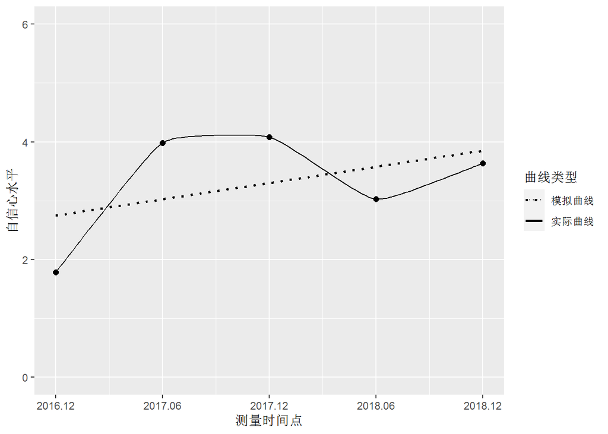

### 第二部分 家长教养方式

下图为过去三年家长教养方式的变化曲线：

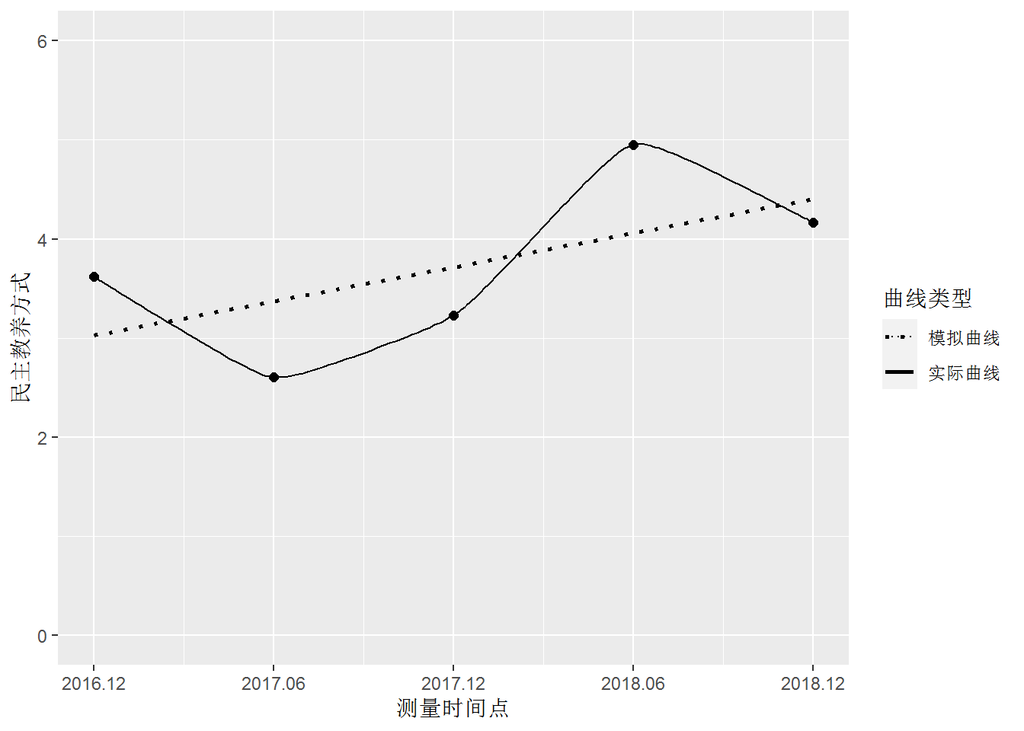

### 第三部分 教养方式与幼儿自信心发展的关系

下图以小班上学期的家长教养方式和大班上学期幼儿自信心为例，探讨前期家长工作对幼儿自信心的影响：

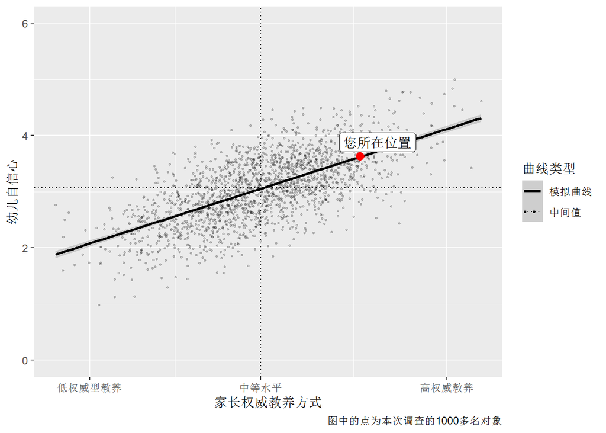

该结果表明您的孩子发展较好，这有赖于您与孩子之间良好的亲子关系，从已有的研究和当前的调查群体来看，良好的教养方式有益于孩子自信心的增长，这种关系需要您进一步的关注。如在日常生活中多关注孩子的情绪，为孩子提供必要的互动支持等。